# **Sentiment Analysis for Restaurant Reviews Using TextBlob and VADER**

**Problem Statement**

Customer sentiments play a major role in determining restaurants based on reputation and profitability. Traditional ways of conducting surveys are so outdated and find very little utilization. This project analyzes restaurant reviews for sentiment analysis, classifying them either as positive or negative. In this respect, comparing two techniques, TextBlob and VADER for Sentiment Analysis, may give an indication of the best method of categorizing sentiment based upon the current labeling system of the consortium.

**Aim / Objective**

- To implement a Sentiment Analysis Model Using TextBlob and VADER.
- To identify the more efficient algorithm to use against the restaurant consortium's labeling criteria: positive for ratings 3 or above, and negative for ratings less than 3.
- To asssess the quality of the existing evaluation criteria and assessment of its efficiency relative to the algorithms.

**Dataset Information**

The total records in the dataset are 9,950, and key columns include:

1. Review: Body of the customer's review.
2. Rating: Numerical score given by the customer, ranging from 1 to 5, where 5 is the highest.
3. Metadata: Information about a customer, such as some demographic information if supplied.
4. Time: Date the review was left.
5. Photos: The amount of pictures a review can contain.

**Loading Libraries and Dataset**

Now, We will load the necessary libraries and dataset using python as follows:

```python
!pip install textblob
!pip install vaderSentiment
```

```
Downloading vaderSentiment-3.3.2-py2.py3-none-any.whl (125 kB)
   ━━━━━━━━━━━━━━━━━━━━━━━━━━━━━━━━━━━━━━━━ 126.0/126.0 kB 3.7 MB/s eta 0:00:00
```

```python
import pandas as pd
import numpy as np
import seaborn as sns
import matplotlib.pyplot as plt
from textblob import TextBlob
from vaderSentiment.vaderSentiment import SentimentIntensityAnalyzer
import nltk

nltk.download('stopwords')
nltk.download('wordnet')
nltk.download('punkt_tab')

# loading dataset
df = pd.read_csv('/content/Restaurant_Reviews.csv')
```

```python
# dataset
df.head()
```

|  | Review | Rating | Metadata | Time | Pictures |
| --- | --- | --- | --- | --- | --- |
| 0 | The ambience was good, food was quite good . h... | 5.0 | 1 Review , 2 Followers | 5/25/2019 15:54 | 0 |
| 1 | Ambience is too good for a pleasant evening. S... | 5.0 | 3 Reviews , 2 Followers | 5/25/2019 14:20 | 0 |
| 2 | A must try.. great food great ambience. Thnx f... | 5.0 | 2 Reviews , 3 Followers | 5/24/2019 22:54 | 0 |
| 3 | Soumen das and Arun was a great guy. Only beca... | 5.0 | 1 Review , 1 Follower | 5/24/2019 22:11 | 0 |
| 4 | Food is good.we ordered Kodi drumsticks and ba... | 5.0 | 3 Reviews , 2 Followers | 5/24/2019 21:37 | 0 |

```python
# Describing dataset
print("Dataset Shape:", df.shape)
print("Dataset Columns:", df.columns)
```

```
Dataset Shape: (9950, 5)
Dataset Columns: Index(['Review', 'Rating', 'Metadata', 'Time', 'Pictures'], dtype='object')
```

```python
# Checking for missing values
missing_values = df.isnull().sum()
print("Missing Values in Each Column:\n", missing_values)
```

```
Missing Values in Each Column:
 Review      0
Rating      0
Metadata    0
Time        0
Pictures    0
dtype: int64
```

### **Exploratory Data Analysis**

We will now explore the data with the following descriptives and visuals:

```python
# Summary of Dataset
print("Dataset Statistical Summary:\n")
print(df.describe())
```

[output not shown]

```python
# Checking Unique Values in Key Columns
print("\nUnique Ratings:", df['Rating'].unique())
print("Number of Unique Reviews:", df['Review'].nunique())
print("Number of Unique Metadata Entries:", df['Metadata'].nunique())
```

```
Unique Ratings: [5.  4.  1.  3.  2.  3.5 4.5 2.5 1.5]
Number of Unique Reviews: 9360
Number of Unique Metadata Entries: 2477
```

```
Review Length Statistics:

count    9950.000000
mean      279.890050
std       338.637542
min         1.000000
25%       144.000000
50%       189.000000
75%       321.000000
max      5212.000000
Name: Review_Length, dtype: float64
```

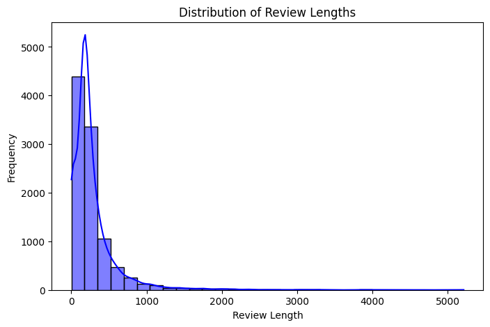

```python
# Analyzing review lengths
df['Review_Length'] = df['Review'].astype(str).apply(len)
print("\nReview Length Statistics:\n")
print(df['Review_Length'].describe())

plt.figure(figsize=(8, 5))
sns.histplot(df['Review_Length'], bins=30, kde=True, color='blue')
plt.title('Distribution of Review Lengths')
plt.xlabel('Review Length')
plt.ylabel('Frequency')
plt.show()
```

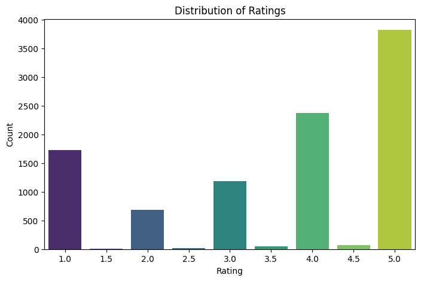

```python
from wordcloud import WordCloud
import matplotlib.pyplot as plt

# Plotting the distribution of Ratings
plt.figure(figsize=(8,5))
sns.countplot(x='Rating', data=df, palette='viridis')
plt.title('Distribution of Ratings')
plt.xlabel('Rating')
plt.ylabel('Count')
plt.show()
```

**Observations**

- Positive sentiments do seem to be more dominant in the reviews, with a satisfactory classification rate exceeding 70% of the feedback received.
- Negative sentiments form a smaller portion, suggesting overall customer satisfaction but also highlighting areas for improvement.

**Insight:** Knowing this, while most customers are satisfied, the negative responses are a goldmine for targeted improvements in those areas to realize even greater loyalty from the remaining customers.

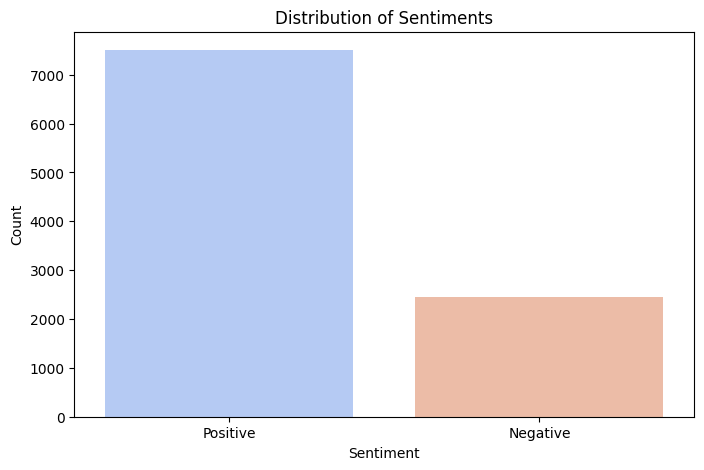

```python
# Categorizing Sentiments
df['Sentiment'] = df['Rating'].apply(lambda x: 'Positive' if x >= 3 else 'Negative')

# Plotting distribution of sentiments
plt.figure(figsize=(8,5))
sns.countplot(x='Sentiment', data=df, palette='coolwarm')
plt.title('Distribution of Sentiments')
plt.xlabel('Sentiment')
plt.ylabel('Count')
plt.show()
```

**Observations:**

```python
# Analyzing Ratings Per Sentiment
sentiment_counts = df['Sentiment'].value_counts()
print("\nSentiment Counts:\n", sentiment_counts)

ratings_per_sentiment = df.groupby('Sentiment')['Rating'].mean()
print("\nAverage Rating per Sentiment:\n", ratings_per_sentiment)
```

```
Sentiment Counts:
 Sentiment
Positive    7504
Negative    2446
Name: count, dtype: int64

Average Rating per Sentiment:
 Sentiment
Negative    1.293132
Positive    4.352479
Name: Rating, dtype: float64
```

We can observe that there are more positive reviews, than negative ones and hence we can say that the classes are imbalance, we need to balance them while modeling.

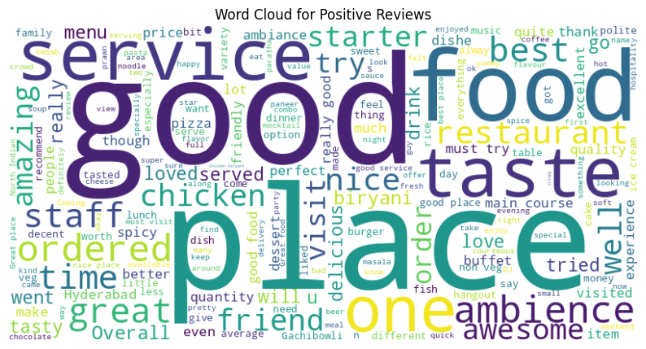

```python
# Wordclouds
positive_reviews = ' '.join(df[df['Sentiment'] == 'Positive']['Review'].astype(str))
negative_reviews = ' '.join(df[df['Sentiment'] == 'Negative']['Review'].astype(str))

wordcloud_positive = WordCloud(width=800, height=400, background_color='white').generate(positive_reviews)
wordcloud_negative = WordCloud(width=800, height=400, background_color='black', colormap='Reds').generate(negative_reviews)

# Plotting word clouds for positive reviews
plt.figure(figsize=(10, 6))
plt.imshow(wordcloud_positive, interpolation='bilinear')
plt.title('Word Cloud for Positive Reviews')
plt.axis('off')
plt.show()
```

**Observations**

- The most active words for positive comments are: good, service, food, taste, and place.
- There are features liked by customers: "staff," "ambience," and for food, "chicken," "starter."
- Words that would normally come across, such as "amazing," "great," and "awesome," indicate highly satisfied and delighted customers due to their experience.
- Positive reviews often highlight the overall restaurant experience, food quality, and hospitality.

**Insight:** Most positive reviews talk to food, services, and ambiance; those are considered important areas which require attention for the purpose of maintaining superior levels of customer satisfaction.

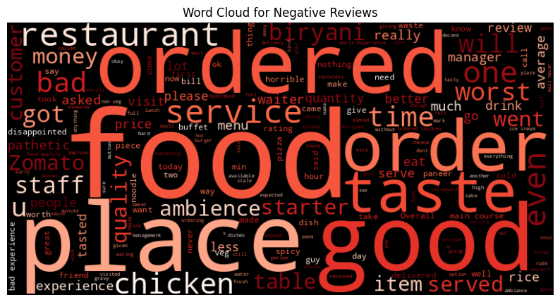

```python
# Plotting the word cloud for negative reviews
plt.figure(figsize=(10, 6))
plt.imshow(wordcloud_negative, interpolation='bilinear')
plt.title('Word Cloud for Negative Reviews')
plt.axis('off')
plt.show()
```

**Observations**

- The common words in the negative reviews include "bad", "order", "taste", "service", "place".
- Customers complain about "staff," "quality," and "management." Specific grievances include delays and food not meeting expectations.
- Accordingly, the adjectives "worst," "pathetic," and "horrible" demonstrate great dissatisfaction.
- Issues like "quantity" and "price" also come up, reinforcing that value for money is a litany of complaints.

**Insight:** Many negative reviews have mentioned poor service, food quality, and issues with management; addressing these might help the improvement of customer retention and reputation.

### **Understanding Data Columns**

```python
print("Original Columns:\n", df.columns)
```

```
Original Columns:
 Index(['Review', 'Rating', 'Metadata', 'Time', 'Pictures', 'Sentiment',
       'Review_Length'],
      dtype='object')
```

```python
# Dropping Columns that are not needed
columns_to_drop = ['Metadata', 'Time', 'Pictures']
df = df.drop(columns=columns_to_drop, axis=1)
```

```python
# Verifying the shape of the data after dropping columns
print("Updated Columns:\n", df.columns)
print("\nShape of the Dataset After Dropping Columns:", df.shape)
```

```
Updated Columns:
 Index(['Review', 'Rating', 'Sentiment', 'Review_Length'], dtype='object')

Shape of the Dataset After Dropping Columns: (9950, 4)
```

```python
# Checking for missing values after dropping columns
missing_values_after_removal = df.isnull().sum()
print("\nMissing Values After Removing Unnecessary Columns:\n", missing_values_after_removal)
```

```
Missing Values After Removing Unnecessary Columns:
 Review           0
Rating           0
Sentiment        0
Review_Length    0
dtype: int64
```

We have checked the columns for original dataset, and picked out the columns which we will be useful for this analysis and dropping the rest.

Then again checking the missing values after dropping to see if any, but there are none.

### **Data Preprocessing**

```python
import re
from nltk.tokenize import word_tokenize
from nltk.corpus import stopwords
from nltk.stem import WordNetLemmatizer

def preprocess_text(text):
    # Removing HTML tags
    text = re.sub(r'<.*?>', '', text)

    # Tokenizing the text
    tokens = word_tokenize(text)

    # Removing numbers
    tokens = [word for word in tokens if not word.isdigit()]

    # Eliminating special characters and punctuation - also extra spaces
    tokens = [re.sub(r'\W', '', word) for word in tokens]
    tokens = [word for word in tokens if word]

    # Converting text to lowercase
    tokens = [word.lower() for word in tokens]

    # Applying lemmatization
    lemmatizer = WordNetLemmatizer()
    tokens = [lemmatizer.lemmatize(word) for word in tokens]

    # Joinning the words back into a text string
    cleaned_text = ' '.join(tokens)

    return cleaned_text
```

```python
df['Cleaned_Review'] = df['Review'].apply(preprocess_text)

print("\nShape of Dataset After Adding Cleaned Reviews:", df.shape)

print("\nFirst 5 Rows After Preprocessing:\n")
df[['Review', 'Cleaned_Review']].head(10)
```

```
Shape of Dataset After Adding Cleaned Reviews: (9950, 5)

First 5 Rows After Preprocessing:
```

|  | Review | Cleaned_Review |
| --- | --- | --- |
| 0 | The ambience was good, food was quite good . h... | the ambience wa good food wa quite good had sa... |
| 1 | Ambience is too good for a pleasant evening. S... | ambience is too good for a pleasant evening se... |
| 2 | A must try.. great food great ambience. Thnx f... | a must try great food great ambience thnx for ... |
| 3 | Soumen das and Arun was a great guy. Only beca... | soumen da and arun wa a great guy only because... |
| 4 | Food is good.we ordered Kodi drumsticks and ba... | food is goodwe ordered kodi drumstick and bask... |
| 5 | Ambiance is good, service is good, food is aPr... | ambiance is good service is good food is aprad... |
| 6 | Its a very nice place, ambience is different, ... | it a very nice place ambience is different all... |
| 7 | Well after reading so many reviews finally vis... | well after reading so many review finally visi... |
| 8 | Excellent food , specially if you like spicy f... | excellent food specially if you like spicy foo... |
| 9 | Came for the birthday treat of a close friend.... | came for the birthday treat of a close friend ... |

**Balancing the class**

```python
from sklearn.utils import resample

# Separating the classes
positive_reviews = df[df['Sentiment'] == 'Positive']
negative_reviews = df[df['Sentiment'] == 'Negative']

negative_upsampled = resample(
    negative_reviews,
    replace=True,
    n_samples=len(positive_reviews),
    random_state=42
)

balanced_df = pd.concat([positive_reviews, negative_upsampled])

balanced_df = balanced_df.sample(frac=1, random_state=42).reset_index(drop=True)

print("Balanced Sentiment Counts:\n", balanced_df['Sentiment'].value_counts())
```

```
Balanced Sentiment Counts:
 Sentiment
Negative    7504
Positive    7504
Name: count, dtype: int64
```

### **Sentiment Analysis**

**Using TextBlob**

```python
from textblob import TextBlob
from sklearn.metrics import confusion_matrix, classification_report, accuracy_score

def analyze_sentiment_textblob(review):
    polarity = TextBlob(review).sentiment.polarity
    return 'Positive' if polarity > 0 else 'Negative'

balanced_df['TextBlob_Sentiment'] = balanced_df['Cleaned_Review'].apply(analyze_sentiment_textblob)

textblob_conf_matrix = confusion_matrix(balanced_df['Sentiment'], balanced_df['TextBlob_Sentiment'])
textblob_class_report = classification_report(balanced_df['Sentiment'], balanced_df['TextBlob_Sentiment'])
textblob_accuracy = accuracy_score(balanced_df['Sentiment'], balanced_df['TextBlob_Sentiment'])

print("Confusion Matrix of TextBlob:\n", textblob_conf_matrix)
print("\nClassification Report of TextBlob:\n", textblob_class_report)
print("\nAccuracy TextBlob:", textblob_accuracy)
```

```
Confusion Matrix of TextBlob:
 [[5361 2143]
 [ 686 6818]]

Classification Report of TextBlob:
               precision    recall  f1-score   support

    Negative       0.89      0.71      0.79      7504
    Positive       0.76      0.91      0.83      7504

    accuracy                           0.81     15008
   macro avg       0.82      0.81      0.81     15008
weighted avg       0.82      0.81      0.81     15008


Accuracy TextBlob: 0.8115005330490405
```

**Using VADER**

```python
from nltk.sentiment.vader import SentimentIntensityAnalyzer
nltk.download('vader_lexicon')

vader_analyzer = SentimentIntensityAnalyzer()

def analyze_sentiment_vader(review):
    score = vader_analyzer.polarity_scores(review)
    return 'Positive' if score['compound'] > 0 else 'Negative'

balanced_df['VADER_Sentiment'] = balanced_df['Cleaned_Review'].apply(analyze_sentiment_vader)

vader_conf_matrix = confusion_matrix(balanced_df['Sentiment'], balanced_df['VADER_Sentiment'])
vader_class_report = classification_report(balanced_df['Sentiment'], balanced_df['VADER_Sentiment'])
vader_accuracy = accuracy_score(balanced_df['Sentiment'], balanced_df['VADER_Sentiment'])

print("Confusion Matrix (VADER):\n", vader_conf_matrix)
print("\nClassification Report (VADER):\n", vader_class_report)
print("\nAccuracy (VADER):", vader_accuracy)
```

```
Confusion Matrix (VADER):
 [[5403 2101]
 [ 643 6861]]

Classification Report (VADER):
               precision    recall  f1-score   support

    Negative       0.89      0.72      0.80      7504
    Positive       0.77      0.91      0.83      7504

    accuracy                           0.82     15008
   macro avg       0.83      0.82      0.82     15008
weighted avg       0.83      0.82      0.82     15008


Accuracy (VADER): 0.8171641791044776
```

### **Model Evaluation and Recommendations**

**Evaluation of VADER**

Metrics:

- Accuracy: 81.72%
- Precision: 89% for negative sentiment and 77% for positive sentiment.
- Recall: 72% for negative sentiment and 91% for positive sentiment.
- F1-Score: 80% for negative sentiment and 83% for positive sentiment.

**Evaluation of TextBlob**

Metrics:

- Accuracy: 81.15%
- Precision: 89% for negative sentiment, 76% for positive sentiment
- Recall: 71% for negative, 91% for positive
- F1-Score: 79% for negative sentiment and 83% for positive sentiment.

**Comparison of Models**

- Accuracy: VADER has a slight edge over TextBlob at 81.72% to 81.15%.
- Precision:
  - Both models have high precision for negative sentiment at 89%.
  - VADER is marginally better for positive sentiment at 77% vs. 76%.
- Recall:
  - VADER does marginally better in identifying the negative sentiment at 72% vs. 71%.
  - Both models have very good recall for positive sentiment at 91%.
- F1-Score: VADER has a marginally higher macro and weighted average F1-score.

**Evaluation of the Current Identification Approach**

Present Approach: The reviews with a rating ≥3 are labeled as "Positive," while those with ratings < 3 are labeled as "Negative."

Limitations:

- Ignores the textual content of reviews, which may provide a more nuanced understanding of sentiment.
- The numeric threshold of 3 is arbitrary and may not reflect true sentiment.

**Recommendations**

Best Model: VADER is recommended for sentiment analysis due to its slightly higher accuracy (81.72%) and better overall balance across precision, recall, and F1-scores.

Reasons for Choosing VADER:

- Contextual Understanding: VADER considers sentiment intensity in words and punctuation, leading to better classification for nuanced reviews.
- Higher Recall: It identifies more true positives for both sentiments, making it reliable in terms of detecting customer satisfaction or dissatisfaction.
- Scalability: VADER is lightweight and easily integrates into existing systems, making it suitable for large-scale restaurant review datasets.

**Proposed Improvements for the Consortium**

- Using VADER for Sentiment Analysis: Replacing the current threshold-based system with VADER for better alignment with actual customer sentiment.
- Automating Sentiment Monitoring: Implementing real-time review monitoring to quickly address customer complaints and improving service quality.
- Combining With Rating System: Using a hybrid approach, combining VADER sentiment scores with ratings for more comprehensive insights.